# Mapping the HDL proteome in Metabolic Syndrome through label-free quantification.

Elvira Márquez Paradas

2023-06-05

The packages required for the execution of this script can be loaded below:

```r
# List of packages to be used
packages_cran <- c("tidyverse", "ggplot2", "tidyr", "stats", "factoextra","FactoMineR")
packages_bioconductor <- c("limma", "clusterProfiler", "org.Hs.eg.db", "treemap")

# Check if CRAN packages are installed and, if not, install them.
for (package in packages_cran) {
  if (!requireNamespace(package, quietly = TRUE)) {
    install.packages(package)
  }
}

# Check if the Bioconductor packages are installed and, if not, install them.
if (!requireNamespace("BiocManager", quietly = TRUE)) {
  install.packages("BiocManager")
}
BiocManager::install(packages_bioconductor)
# Load packages
library(tidyverse)
library(ggplot2)
library(tidyr)
library(stats)
library(factoextra)
library(limma)
library(FactoMineR)
library(clusterProfiler)
library(org.Hs.eg.db)
library(treemap)
```

## DATA PREPROCESSING

First, we load the data, select the columns of interest and rename them to facilitate the analysis. We have proteomics data from 17 healthy patients and 20 patients with Metabolic Syndrome. For the analysis, we will use the **LFQ intensity**, which will allow the comparison of the relative abundance of proteins between different samples.

```r
patients <- read.table("./data/proteinGroups.txt", header = T, sep = "\t", na.strings = "NaN")
dim(patients)
```

```
## [1] 580 371
```

```r
patients <- dplyr::select(patients, select = c("Protein.IDs", "Protein.names", "Gene.names",
                                        matches("^LFQ.intensity."), "Only.identified.by.site", "Reverse", "Potential.contaminant"))

names <- read.table("./data/names.txt", sep = "\n")[,1]
colnames(patients)=names
```

The number of proteins before data pre-processing is 580. Let’s check the behavior of the samples before data pre-processing

```r
# Reorganization of data
#####
patients.pca= patients[,-c(1:3,41:43)]
pca.data<- data.frame(colnames(patients.pca),t(patients.pca))
colnames(pca.data)[1] <- "Sample"
pca.data[, -1] <- scale(pca.data[, -1], center = T, scale = F)

# Principal Component Analysis
#####
res.pca <- PCA(pca.data[,-1], graph = F,scale.unit = F, ncp = 10 )
res.pca$eig
```

```
##           eigenvalue percentage of variance cumulative percentage of variance
## comp 1  5.494144e+14           36.822243976                          36.82224
## comp 2  2.591205e+14           17.366486773                          54.18873
## comp 3  1.690400e+14           11.329210408                          65.51794
## comp 4  1.325280e+14            8.882142876                          74.40008
## comp 5  9.641057e+13            6.461522151                          80.86161
## comp 6  6.553888e+13            4.392474422                          85.25408
## comp 7  4.819319e+13            3.229950678                          88.48403
## comp 8  3.600409e+13            2.413025920                          90.89706
## comp 9  2.421058e+13            1.622614342                          92.51967
## comp 10 2.058846e+13            1.379856904                          93.89953
## comp 11 1.567178e+13            1.050336908                          94.94987
## comp 12 1.489554e+13            0.998312114                          95.94818
## comp 13 1.184766e+13            0.794040681                          96.74222
## comp 14 6.835870e+12            0.458146090                          97.20036
## comp 15 6.067332e+12            0.406638019                          97.60700
## comp 16 5.176256e+12            0.346917313                          97.95392
## comp 17 4.247458e+12            0.284668388                          98.23859
## comp 18 4.035611e+12            0.270470238                          98.50906
## comp 19 3.281401e+12            0.219922396                          98.72898
## comp 20 3.031766e+12            0.203191656                          98.93217
## comp 21 2.870896e+12            0.192409992                          99.12458
## comp 22 2.453365e+12            0.164426702                          99.28901
## comp 23 2.307116e+12            0.154624944                          99.44363
## comp 24 1.706897e+12            0.114397732                          99.55803
## comp 25 1.265546e+12            0.084818052                          99.64285
## comp 26 1.034471e+12            0.069331192                          99.71218
## comp 27 8.603902e+11            0.057664115                          99.76984
## comp 28 7.808627e+11            0.052334113                          99.82218
## comp 29 5.532908e+11            0.037082046                          99.85926
## comp 30 4.803158e+11            0.032191190                          99.89145
## comp 31 4.139814e+11            0.027745405                          99.91920
## comp 32 3.586273e+11            0.024035520                          99.94323
## comp 33 3.281970e+11            0.021996055                          99.96523
## comp 34 2.031540e+11            0.013615563                          99.97884
## comp 35 1.700448e+11            0.011396552                          99.99024
## comp 36 1.456050e+11            0.009758577                         100.00000
```

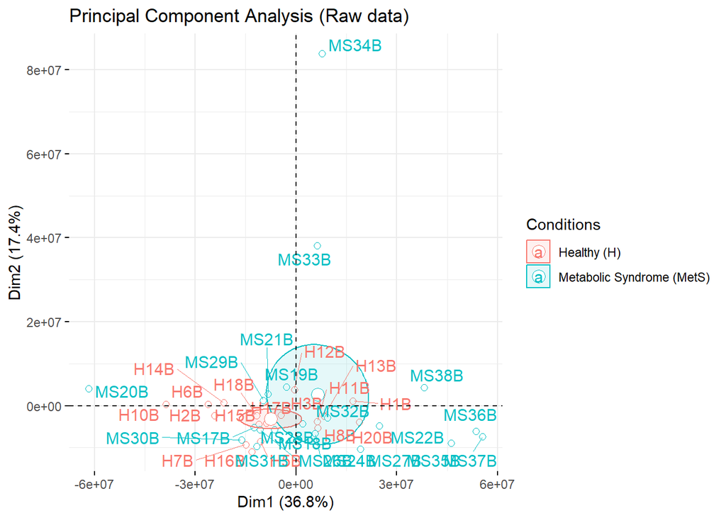

```r
# Individual plot
#####
H <- rep("Healthy (H)", 17)
MS <- rep("Metabolic Syndrome (MetS)", 20)
fviz_pca_ind(res.pca, col.ind = c(H,MS),
             pointsize=2, pointshape=21, fill="white",
             repel = TRUE,
             addEllipses = TRUE,ellipse.type = "confidence",
             ellipse.level= 0.95,
             legend.title="Conditions",
             title="Principal Component Analysis (Raw data)",
             show_legend=TRUE,show_guide=TRUE)
```

We replace the 0’s by missing values (NA) and transforme the data to logarithmic scale to decrease the variance and homogenize the data.

```r
# 0's deletion
#####
patients[patients == 0] <- NA

# Log2 transformation
#####
cols <- names(patients)[grepl("^H|^MS", names(patients))]
patients[cols] <- lapply(patients[cols], log2)
```

We filter the proteins, eliminating reversed proteins, dentified only by site, and potential contaminants. Finally, we remove from the dataset those columns that will not be used again.

```r
patients <- patients %>% filter(Potential.contaminant != "+" & Only.identified.by.site != "+" & Reverse != "+")
dim(patients)
```

```
## [1] 528  43
```

```r
patients <- patients %>% dplyr::select(-any_of(c("Potential.contaminant","Only.identified.by.site", "Reverse")))
data <- patients
```

After the tidying up the data, the missing values have to be dealt with. Only proteins that have been detected in at least 70% of the samples will be taken into account.

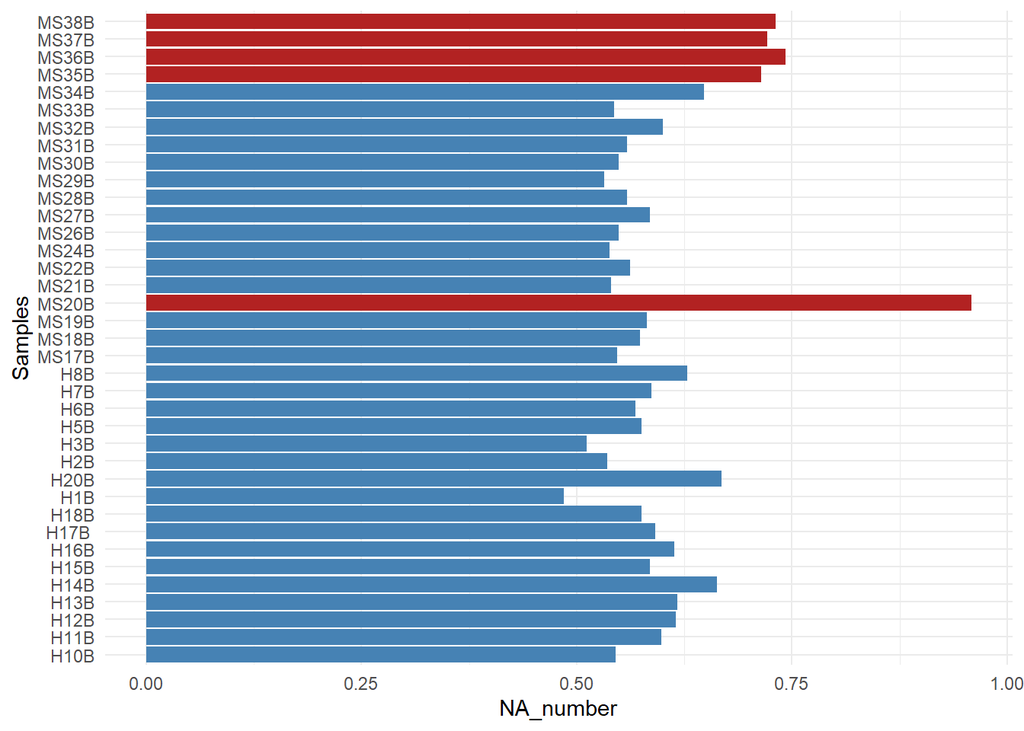

```r
temp <- data.frame(Samples=colnames(data), NA_number=colSums(is.na(data))/nrow(data))
temp=temp[-c(1:3),]
ggplot(temp, aes(x=NA_number, y= Samples)) +
  geom_bar(stat = "identity", fill = ifelse (temp$NA_number >= 0.7 ,
                                             "firebrick","steelblue")) +
  theme_minimal()
```

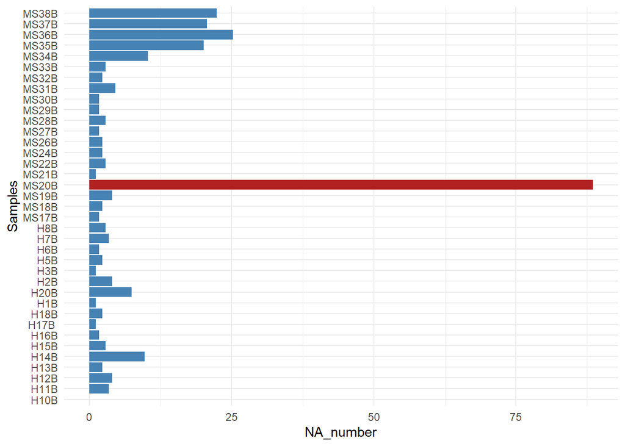

```r
# In red, all the samples with more than 30% of missing values. Compare it afterwards
# the removal of those noisy proteins:

data <- data[which(rowMeans(!is.na(data))> 0.7),]
temp <- data.frame(Samples = colnames(data), NA_number = colSums(is.na(data)) / nrow(data) * 100)
temp=temp[-c(1:3),]
ggplot(temp, aes(x=NA_number, y= Samples)) +
  geom_bar(stat = "identity", fill = ifelse (temp$NA_number >= 70 ,
                                             "firebrick","steelblue")) +
  theme_minimal()
```

```r
dim(data)
```

```
## [1] 174  40
```

```r
write.table(temp, file = "./data/data_preproccessed.txt", sep = "\t", quote = F, row.names = F)
```

In general, there are not too many missing values after preprocessing,, but 1 sample stands out with a notably higher number than the rest. The MS20 patient has more than 80% of missing values, probably due to experimental errors in the sample. This sample is eliminated for further analysis. After preprocessing, the total number of proteins is 174. Finally, we will reorganize the data in a matrix for the following steps.

```r
# Removal of patient MS20
#####
data <- subset(data, select = -MS20B)

# Reorganization of data into a matrix table for next steps
#####
protein.id <- data$Protein.IDs
Gene.names=data$Gene.names
data=data[,-c(1:3)]
protein.id <- gsub(";.+", "",protein.id)  #Keep only the first accession number
rownames(data)=protein.id
data=data.matrix(data)
dim(data)
```

```
## [1] 174  36
```

*Normalization of the dataset:* the distribution of the data should be checked, before and after the normalization. A multiple Shapiro Wilkinson test will be performed to each protein intensity in order to check the normality. The p values obtained will be adjusted by an stringent method (Holm method 1979).

```r
counts <- 2^data
p_values <- data.frame(protein.id=rownames(counts),
                       p.value=apply( counts,1, function(x) shapiro.test(x)$p.value))
p_values$adj.p.val <- p.adjust(p_values$p.value, method = "holm")
table(p_values$adj.p.val>0.05)
```

```
##
## FALSE  TRUE
##    56   118
```

We observe that 118 of the 174 proteins conforme to a normal distribution. We visualise the distribution of intensities in each sample before normalisation.

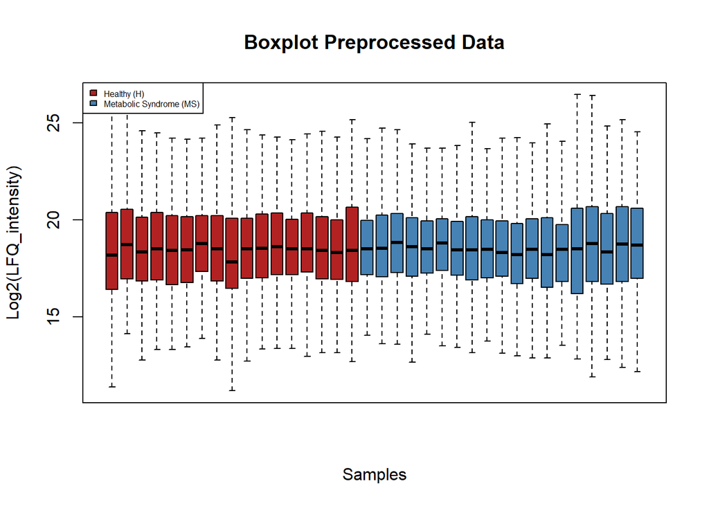

```r
y_axis_title = "Log2(LFQ_intensity)"
x_axis_title = "Samples"
main_title = "Boxplot Preprocessed Data"
colors <- c(rep("firebrick", 17), rep("steelblue", 19))
boxplot(data, outline = FALSE, col = colors, cex.lab = 1.5, xaxt = "n")
title(ylab = y_axis_title, xlab=x_axis_title)
title(main = main_title, cex.main = 1.2)
legend("topleft", legend = c("Healthy (H)", "Metabolic Syndrome (MS)"), fill = c("firebrick", "steelblue"), cex = 0.5)
```

Since a large number of proteins fit a normal distribution, and the behavior of the samples is quite homogeneous, we decided not to apply any normalization method. We will work with the data transformed to logarithmic scale.

*Principal Component Analysis (PCA):* Next, in order to identify patterns of interest, detect possible outliers and visualize whether there are different proteomic profiles in both study groups, we performed dimensionality reduction using PCA.

```r
# Reorganization of data
#####
pca.data<- data.frame(colnames(data),t(data))
colnames(pca.data)[1] <- "Sample"
pca.data[, -1] <- scale(pca.data[, -1], center = T, scale = F)

pca.data[is.na(pca.data)] <- 0    #Imputation of NA values by zero
table(is.na(pca.data))
```

```
##
## FALSE
##  6300
```

```r
pca.data.mixomics=t(pca.data)
data.omics=cbind(Gene.names,pca.data.mixomics[-1,])
write.table(data.omics, file = "./data/preprocessed_data_cero_imputed.txt", sep = "\t", quote = F, row.names = F)

# Principal Component Analysis
#####
res.pca <- PCA(pca.data[,-1], graph = F,scale.unit = F, ncp = 10 )
res.pca$eig
```

```
##         eigenvalue percentage of variance cumulative percentage of variance
## comp 1  28.9899729             18.2113843                          18.21138
## comp 2  20.8329439             13.0871715                          31.29856
## comp 3  13.5106778              8.4873534                          39.78591
## comp 4  12.7586907              8.0149581                          47.80087
## comp 5   9.2032120              5.7814208                          53.58229
## comp 6   7.8136799              4.9085223                          58.49081
## comp 7   6.8601513              4.3095194                          62.80033
## comp 8   5.9268889              3.7232478                          66.52358
## comp 9   4.9974329              3.1393673                          69.66294
## comp 10  4.1908021              2.6326450                          72.29559
## comp 11  4.0677195              2.5553250                          74.85091
## comp 12  3.3456684              2.1017354                          76.95265
## comp 13  3.2885786              2.0658718                          79.01852
## comp 14  3.1066248              1.9515692                          80.97009
## comp 15  2.9672860              1.8640371                          82.83413
## comp 16  2.7904873              1.7529729                          84.58710
## comp 17  2.3549452              1.4793671                          86.06647
## comp 18  2.1997603              1.3818805                          87.44835
## comp 19  2.0251401              1.2721849                          88.72053
## comp 20  1.9566316              1.2291481                          89.94968
## comp 21  1.8685637              1.1738242                          91.12351
## comp 22  1.6258356              1.0213434                          92.14485
## comp 23  1.4720245              0.9247199                          93.06957
## comp 24  1.3838413              0.8693235                          93.93889
## comp 25  1.2763669              0.8018085                          94.74070
## comp 26  1.1993879              0.7534506                          95.49415
## comp 27  1.1751837              0.7382457                          96.23240
## comp 28  0.9949911              0.6250494                          96.85745
## comp 29  0.9289793              0.5835811                          97.44103
## comp 30  0.8754399              0.5499479                          97.99098
## comp 31  0.7988844              0.5018560                          98.49283
## comp 32  0.6857549              0.4307884                          98.92362
## comp 33  0.6511892              0.4090744                          99.33270
## comp 34  0.5463894              0.3432396                          99.67593
## comp 35  0.5158665              0.3240652                         100.00000
```

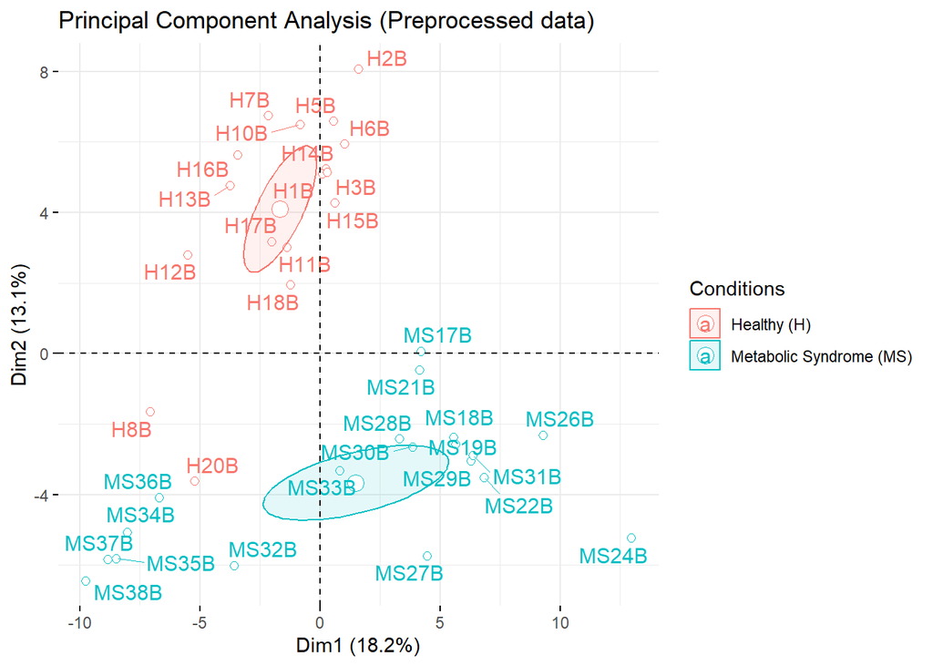

```r
# Individual plot
#####
H <- rep("Healthy (H)", 17)
MS <- rep("Metabolic Syndrome (MS)", 19)
fviz_pca_ind(res.pca, col.ind = c(H,MS),
             pointsize=2, pointshape=21, fill="white",
             repel = TRUE,
             addEllipses = TRUE,ellipse.type = "confidence",
             ellipse.level= 0.95,
             legend.title="Conditions",
             title="Principal Component Analysis (Preprocessed data)",
             show_legend=TRUE,show_guide=TRUE)
```

In order to maintain a conservative approach and avoid risky assumptions, missing values will be imputed by 0. This dataset will be used later for the differential expression analysis and the performance of the sPLS-DA.

```r
# Imputation of missing data values to 0
####
data.mean=data
na_values = is.na(data)
data[na_values]=0
```

On the other hand, in order to avoid possible biases in the analysis of linear correlations and logistic regression, we will create a dataset with the missing values imputed by the mean of each group.

```r
# Imputation of missing data values by mean
####
h= data.mean[, grepl("^H", colnames(data.mean))]
ms= data.mean[, grepl("MS", colnames(data.mean))]

imp.data.h = h
for (i in 1:nrow(h)){
  imp.data.h[i,is.na(imp.data.h[i,])] <- mean(imp.data.h[i,], na.rm = T)
}

imp.data.ms = ms
for (i in 1:nrow(ms)){
  imp.data.ms[i,is.na(imp.data.ms[i,])] <- mean(imp.data.ms[i,], na.rm = T)
}

# Download mean imputed dataset for linear correlation and logistic regression analysis
#####
imp.data=cbind(imp.data.h,imp.data.ms)
data.preprocessed=cbind(Gene.names,imp.data)
write.table(data.preprocessed, file = "./data/preprocessed_data_mean_imputed.txt", sep = "\t", quote = F, row.names = F, dec = ".")
```

## DIFFERENTIAL EXPRESSION ANALYSIS

Next, in order to detect significant differences in the HDL proteome of MetS subjects, we will perform differential expression analysis by fitting the data to a linear regression model using the **Limma** package.

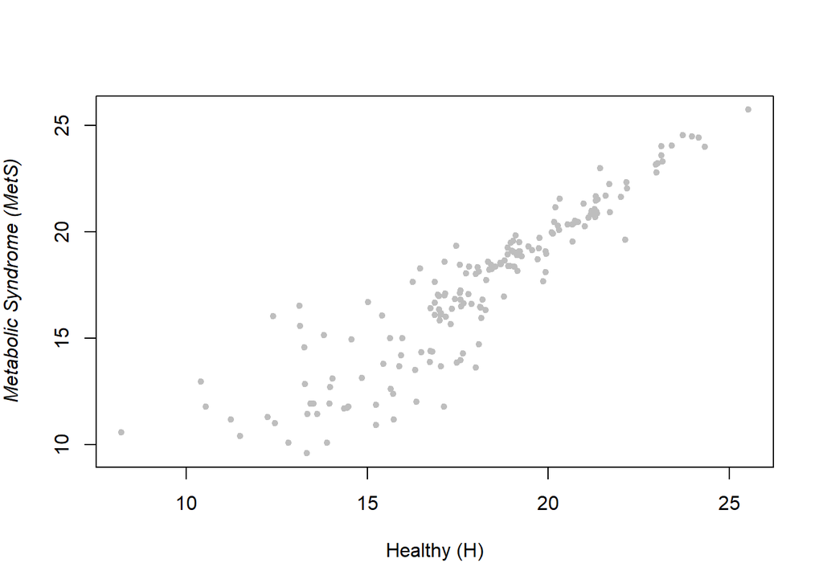

```r
# Elaboration of the average expression matrix
#####
H <- rowMeans(data[, grep("^H", colnames(data))])
MS <- rowMeans(data[, grep("^MS", colnames(data))])
mean.expression <- matrix(c(H,MS),ncol=2)
colnames(mean.expression) <- c("H","MS")
rownames(mean.expression) <- rownames(data)

# Scatterplot to visualize the dispersion between the two conditions
######
plot(H,MS,pch=19,cex=0.7,xlab="Healthy (H)",
     ylab=substitute(italic("Metabolic Syndrome (MetS)")),
     cex.lab=1,
     col="grey")
```

Due to the low number of proteins and the low dispersion observed, we will consider as differentially expressed proteins those with Fold Change > |0.585| and unadjusted p-value < 0.05.

```r
# Linear regression model generation
#####
experimental.design <- model.matrix(~ -1 + factor(c(rep(1, 17), rep(2, 19))))
colnames(experimental.design) <- c("H","MS")
linear.fit <- lmFit(data, experimental.design)
contrast.matrix <- makeContrasts(MS-H,levels=c("H","MS"))
contrast.linear.fit <- contrasts.fit(linear.fit, contrast.matrix)
contrast.results <- eBayes(contrast.linear.fit)
nrow(data)
```

```
## [1] 174
```

```r
H.MS <- topTable(contrast.results, number=174,coef=1,sort.by="logFC")
log.fold.change <- H.MS$logFC
p.value <- H.MS$P.Value
protein.ids <- rownames(H.MS)
length(protein.ids)
```

```
## [1] 174
```

```r
names(log.fold.change) <- protein.ids
names(p.value) <- protein.ids

# Due to the low scattering seen in the scatterplot, we chose a restrictive value logFC
######
activated.protein <- protein.ids[log.fold.change > 0.585  & p.value < 0.05]
repressed.protein <- protein.ids[log.fold.change < -0.585  & p.value < 0.05]

length(activated.protein)   # 13 diferentially overexpressed proteins
```

```
## [1] 13
```

```r
length(repressed.protein)   # 21 diferentially under-expressed proteins
```

```
## [1] 21
```

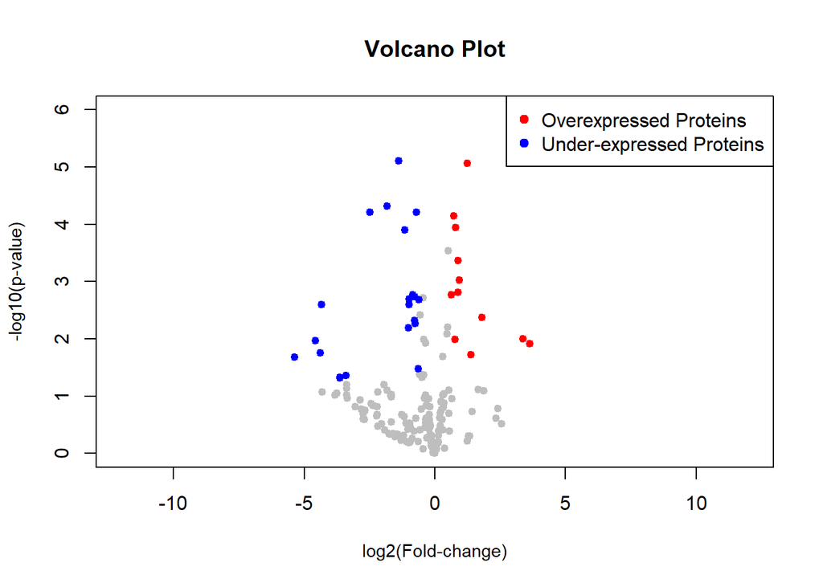

```r
# Volcano plot visualization
######
log.p.val <- -log10(p.value)
plot(log.fold.change,log.p.val,pch=19,col="grey",cex=0.8,
     xlim=c(-12,12),ylim = c(0,6),
     xlab="log2(Fold-change)",ylab="-log10(p-value)",cex.lab=0.9, main="Volcano Plot")

points(x = log.fold.change[activated.protein],
       y = log.p.val[activated.protein],col="red",cex=0.8,pch=19)
points(x = log.fold.change[repressed.protein],
       y = log.p.val[repressed.protein],col="blue",cex=0.8,pch=19)

legend("topright", legend = c("Overexpressed Proteins", "Under-expressed Proteins"),
       col = c("red", "blue"), pch = 19, cex = 1)
```

13 proteins are overexpressed and 21 proteins are under-expressed in the HDL of MetS subjects.

## FUNCTIONAL ENRINCHMENT ANALYSIS

In order to see in which biological processes (BP) the differentially detected proteins are involved, we will perform a functional enrichment analysis using the Gene Ontology (GO) database. Subsequently, we will perform a summary and visualisation of the Biological Process terms using REVIGO.